# Predicting Recession in the United States : A Data Science Tutorial

*Yuze Hu*

## Introduction

As [Retuer](https://www.reuters.com/article/us-usa-economy-recession/u-s-economy-entered-recession-in-february-business-cycle-arbiter-says-idUSKBN23F28L) reported，the U.S. economy ended its longest expansion in history in this February and entered recession. Just after 2 monthes the unemployment rate in U.S. reaches historical high and U.S. GDP is expexted to contract 30% in second quarter, 5% in 2020.

The term Recession represents a business cycle contraction when there is a general decline in economic activity. The business cycle model says the economy always exchange between recession and expansion. The U.S. economy ,following this model, had many recessions in the past, and there are different explanlation to the cause of each recession. This recession in 2020 is often considered to be a result of the [coronavirus pandemic](https://en.wikipedia.org/wiki/Coronavirus_disease_2019). Clearly it is, but are there other factors contribute to the recession? Can we predit this recession before the coronavirus pandemic happens? Should we expect the pandemic to end in the following year? May be we can answer these question with the power of data science.

The tutorial will lead you to find and explore several possible indictors than can be used to predict the economy recession in the future. It will also teach you how to build regression models with chosen indicaters to actually predict the probability of recession in a certain month in the future.

```python
# import lib we need
# we will use numpy and pandas to deal with datas
# pyplot is used to draw graphs
# sklearn.linear_model is used to build regression model
import numpy as np
import pandas as pd
import matplotlib.pyplot as plt
from sklearn import linear_model
from sklearn.model_selection import cross_val_score

#for decision tree and visualization
from sklearn.tree import DecisionTreeClassifier
from IPython.display import Image
from sklearn import tree
import pydotplus
```

If you are unfamilier with the above libraries you can use the following tutorial as reference

- [Pandas tutorial](https://pandas.pydata.org/pandas-docs/stable/getting_started/tutorials.html)
- [Numpy tutorial](https://pandas.pydata.org/pandas-docs/stable/getting_started/install.html)
- [sklearn logistic regression doc](https://scikit-learn.org/stable/modules/generated/sklearn.linear_model.LogisticRegression.html#sklearn.linear_model.LogisticRegression.score)

## Data Collection & Processing & Exploration & Visualization

### Recession peroid

First of all, we need to get the historical recession peroid data. In fact, aprivate economics research group NBER acts as the arbiter for determining U.S. business cycles. We can find recession data on [their website](https://www.nber.org/cycles/). We will use the excel listed on the wesite for labeling recession.

```python
#get recession period and clean up
recess_raw = pd.read_excel("https://www.nber.org/cycles/NBER%20chronology_062020.xlsx")
recess_raw
```

|  | Unnamed: 0 | Unnamed: 1 | Unnamed: 2 | Unnamed: 3 | Unnamed: 4 | Unnamed: 5 | Unnamed: 6 | Unnamed: 7 | Unnamed: 8 | Unnamed: 9 |
| --- | --- | --- | --- | --- | --- | --- | --- | --- | --- | --- |
| 0 | NaN | NaN | NaN | NaN | NaN | NaN | NaN | NaN | NaN | NaN |
| 1 | NaN | NaN | Peak month | Trough month | Peak month number | Trough month number | Duration, peak to trough | Duration, trough to peak | Duration, peak to peak | Duration, trough to trough |
| 2 | NaN | NaN | NaN | December 1854 | NaN | 660 | NaN | NaN | NaN | NaN |
| 3 | NaN | NaN | June 1857 | December 1858 | 690 | 708 | 18 | 30 | NaN | 48 |
| 4 | NaN | NaN | October 1860 | June 1861 | 730 | 738 | 8 | 22 | 40 | 30 |
| ... | ... | ... | ... | ... | ... | ... | ... | ... | ... | ... |
| 56 | NaN | NaN | NaN | NaN | NaN | NaN | NaN | NaN | NaN | NaN |
| 57 | NaN | NaN | NaN | NaN | NaN | NaN | NaN | NaN | NaN | NaN |
| 58 | NaN | NaN | NaN | NaN | NaN | NaN | NaN | NaN | NaN | NaN |
| 59 | NaN | NaN | NaN | NaN | NaN | NaN | NaN | NaN | NaN | NaN |
| 60 | NaN | NaN | NaN | NaN | NaN | NaN | NaN | NaN | NaN | NaN |

61 rows × 10 columns

```python
#first row is infact column name
recess_raw.columns = recess_raw.iloc[1]
recess_raw = recess_raw.iloc[27:37,2:4].apply(pd.to_datetime)
recess = recess_raw.reset_index().iloc[:,1:]
#since we are in the midle of a recession, we need to set the through month manully to the current month
recess["Trough month"][9]  = pd.to_datetime("2020-06-01")
recess
```

| 1 | Peak month | Trough month |
| --- | --- | --- |
| 0 | 1957-08-01 | 1958-04-01 |
| 1 | 1960-04-01 | 1961-02-01 |
| 2 | 1969-12-01 | 1970-11-01 |
| 3 | 1973-11-01 | 1975-03-01 |
| 4 | 1980-01-01 | 1980-07-01 |
| 5 | 1981-07-01 | 1982-11-01 |
| 6 | 1990-07-01 | 1991-03-01 |
| 7 | 2001-03-01 | 2001-11-01 |
| 8 | 2007-12-01 | 2009-06-01 |
| 9 | 2020-02-01 | 2020-06-01 |

Now we are going to find indicators that is prior to 1957 and may have a relationship to the future recession The first possible indicator is Treasury yield spread

### Treasury Yield Spread

Interst rate plays a very critical rule in the more economy. It's the major tool center banks across world inclding federal reserve(Center bank of United States) used to facilitate the economy. You can watch this video provided by Federal Reserve to know more about this :https://www.federalreserve.gov/faqs/why-do-interest-rates-matter.html.

[United States Treasury security](https://en.wikipedia.org/wiki/United_States_Treasury_security) are government debt instruments issued by the United States Department of the Treasury to finance government spending as an alternative to taxation.

The interest rate of Treasury, as a risk-free(or share the risk of the whole economy) loan issued by the government, is the basline of the interest market. Long-short term treasury spread is a pretty classical indicator for the economy. The spread or the difference between the interest rate of long term treasury and the short term treasury generally represent the investor's expectation of the future and the expectation will transform to real economy impact. Sometimes the spread becomes negative menaing that the interate of long term Treasury is lower than the short term Treasury, when this happens there are always a recession within a few years.

You can read this paper for further explanation:https://www.jstor.org/stable/2328836?seq=1

We get treasury rate with different terms from the website of Federal Reserve: https://www.federalreserve.gov/data.htm

We will also include a special columns "fed fund rate" which the average overnight borrowing rate within bank sector. You can consider it as a treasury with a half day term.

After cleaning up the data we get form federal reserve, we will calculate the spread of four different combination of long-short term spread

```python
#get tresury data from federal reserve
treasury_rate_raw = pd.read_csv("https://www.federalreserve.gov/datadownload/Output.aspx?rel=H15&series=c7fcd02fcec21b6486c58c6c92ea81bf&lastobs=&from=01/01/1953&to=07/31/2020&filetype=csv&label=include&layout=seriescolumn")[5:]
treasury_rate_raw.columns = ["date","fed_rate","3m_treasury","1y_treasury","10y_treasury","20y_treasury"]
treasury_rate = treasury_rate_raw.copy()
treasury_rate
```

|  | date | fed_rate | 3m_treasury | 1y_treasury | 10y_treasury | 20y_treasury |
| --- | --- | --- | --- | --- | --- | --- |
| 5 | 1953-01 | NaN | 1.96 | NaN | NaN | NaN |
| 6 | 1953-02 | NaN | 1.97 | NaN | NaN | NaN |
| 7 | 1953-03 | NaN | 2.01 | NaN | NaN | NaN |
| 8 | 1953-04 | NaN | 2.19 | 2.36 | 2.83 | 3.08 |
| 9 | 1953-05 | NaN | 2.16 | 2.48 | 3.05 | 3.18 |
| ... | ... | ... | ... | ... | ... | ... |
| 810 | 2020-02 | 1.58 | 1.52 | 1.41 | 1.50 | 1.81 |
| 811 | 2020-03 | 0.65 | 0.29 | 0.33 | 0.87 | 1.26 |
| 812 | 2020-04 | 0.05 | 0.14 | 0.18 | 0.66 | 1.06 |
| 813 | 2020-05 | 0.05 | 0.13 | 0.16 | 0.67 | 1.12 |
| 814 | 2020-06 | 0.08 | 0.16 | 0.18 | 0.73 | 1.27 |

810 rows × 6 columns

```python
#clean up
#some losing data is marked with NC
treasury_rate.replace("NC",np.nan,inplace=True)
treasury_rate["date"] = pd.to_datetime(treasury_rate["date"])
treasury_rate.iloc[:,1:] = treasury_rate.iloc[:,1:].apply(pd.to_numeric)

#calculate spread data
treasury_rate['3m_10y_spread'] =  treasury_rate["10y_treasury"] -  treasury_rate["3m_treasury"]
treasury_rate['1y_10y_spread'] =  treasury_rate["10y_treasury"] -  treasury_rate["1y_treasury"]
treasury_rate['fed_10y_spread'] =  treasury_rate["10y_treasury"] -  treasury_rate["fed_rate"]
treasury_rate['3m_20y_spread'] =  treasury_rate["20y_treasury"] -  treasury_rate["3m_treasury"]
treasury_rate
```

|  | date | fed_rate | 3m_treasury | 1y_treasury | 10y_treasury | 20y_treasury | 3m_10y_spread | 1y_10y_spread | fed_10y_spread | 3m_20y_spread |
| --- | --- | --- | --- | --- | --- | --- | --- | --- | --- | --- |
| 5 | 1953-01-01 | NaN | 1.96 | NaN | NaN | NaN | NaN | NaN | NaN | NaN |
| 6 | 1953-02-01 | NaN | 1.97 | NaN | NaN | NaN | NaN | NaN | NaN | NaN |
| 7 | 1953-03-01 | NaN | 2.01 | NaN | NaN | NaN | NaN | NaN | NaN | NaN |
| 8 | 1953-04-01 | NaN | 2.19 | 2.36 | 2.83 | 3.08 | 0.64 | 0.47 | NaN | 0.89 |
| 9 | 1953-05-01 | NaN | 2.16 | 2.48 | 3.05 | 3.18 | 0.89 | 0.57 | NaN | 1.02 |
| ... | ... | ... | ... | ... | ... | ... | ... | ... | ... | ... |
| 810 | 2020-02-01 | 1.58 | 1.52 | 1.41 | 1.50 | 1.81 | -0.02 | 0.09 | -0.08 | 0.29 |
| 811 | 2020-03-01 | 0.65 | 0.29 | 0.33 | 0.87 | 1.26 | 0.58 | 0.54 | 0.22 | 0.97 |
| 812 | 2020-04-01 | 0.05 | 0.14 | 0.18 | 0.66 | 1.06 | 0.52 | 0.48 | 0.61 | 0.92 |
| 813 | 2020-05-01 | 0.05 | 0.13 | 0.16 | 0.67 | 1.12 | 0.54 | 0.51 | 0.62 | 0.99 |
| 814 | 2020-06-01 | 0.08 | 0.16 | 0.18 | 0.73 | 1.27 | 0.57 | 0.55 | 0.65 | 1.11 |

810 rows × 10 columns

Now we can get some insights about the realtion between the spread and recession by drawing a spread over time line graph. Look at the following graph, grey region reprecent recession period. You should be able to see a great linear relation ship between the the spread and the (probability of )recession. For evry recession there is a drop in the spread just before the recession and it comes back before the recession ends.

You can also see that the four combinations we choose have a strong correlation with each other.We want to choose one that is smooth(less variance) and sensitive to the future recession. And here we will choose to use 3m_10y_spread, but one should expect similar performance when we choose a different one.

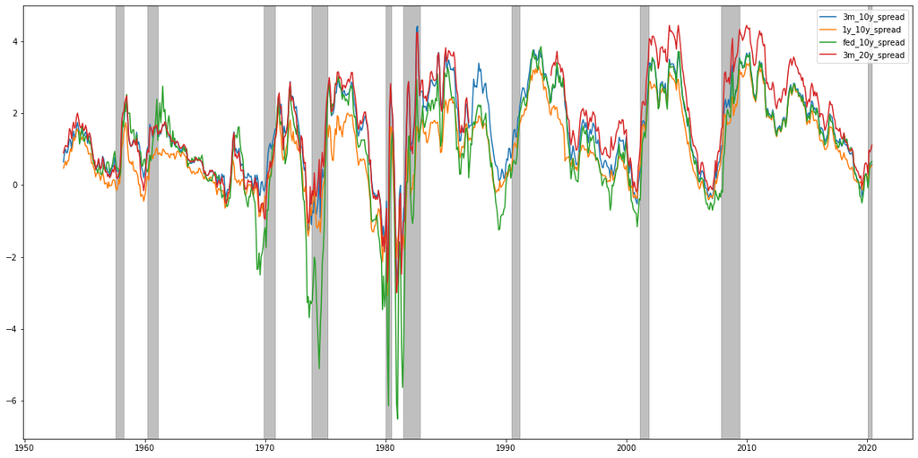

```python
#visualization
fig = plt.figure(figsize=(20,10))
for i in treasury_rate.iloc[ :,-4:] :
    plt.plot(treasury_rate["date"],treasury_rate[[i]],label=i)
plt.legend()
#mark recession period with grey color
for _, row in recess.iterrows() :
    fig.axes[0].axvspan(row["Peak month"],row["Trough month"],color='grey',alpha=0.5)
```

### PPI & CPI

Next we will consider two price index that reflects price change

[The Producer Price Index (PPI)](https://www.bls.gov/ppi/) measures the average change over time in the selling prices received by domestic producers for their output.

[The Consumer Price Index (CPI)](https://www.bls.gov/cpi/) is a measure of the average change over time in the prices paid by urban consumers for a market basket of consumer goods and services.

we can get these two price from fred database https://fred.stlouisfed.org/

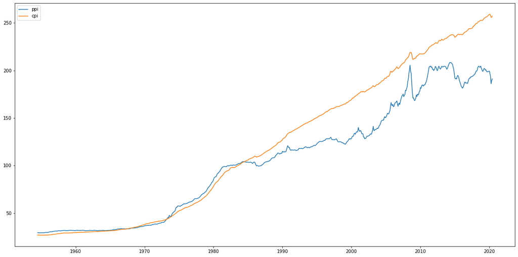

```python
#get ppi data
ppi_full = pd.read_csv("https://fred.stlouisfed.org/graph/fredgraph.csv?bgcolor=%23e1e9f0&chart_type=line&drp=0&fo=open%20sans&graph_bgcolor=%23ffffff&height=450&mode=fred&recession_bars=on&txtcolor=%23444444&ts=12&tts=12&width=1168&nt=0&thu=0&trc=0&show_legend=yes&show_axis_titles=yes&show_tooltip=yes&id=PPIACO&scale=left&cosd=1947-01-01&coed=2020-06-01&line_color=%234572a7&link_values=false&line_style=solid&mark_type=none&mw=3&lw=2&ost=-99999&oet=99999&mma=0&fml=a&fq=Monthly&fam=avg&fgst=lin&fgsnd=2020-02-01&line_index=1&transformation=lin&vintage_date=2020-07-20&revision_date=2020-07-20&nd=1913-01-01")
ppi_full["DATE"] = ppi_full["DATE"].apply(pd.to_datetime)
ppi = ppi_full[90:].copy()

#get cpi data
cpi_full = pd.read_csv("https://fred.stlouisfed.org/graph/fredgraph.csv?bgcolor=%23e1e9f0&chart_type=line&drp=0&fo=open%20sans&graph_bgcolor=%23ffffff&height=450&mode=fred&recession_bars=on&txtcolor=%23444444&ts=12&tts=12&width=1168&nt=0&thu=0&trc=0&show_legend=yes&show_axis_titles=yes&show_tooltip=yes&id=CPIAUCSL&scale=left&cosd=1947-01-01&coed=2020-06-01&line_color=%234572a7&link_values=false&line_style=solid&mark_type=none&mw=3&lw=2&ost=-99999&oet=99999&mma=0&fml=a&fq=Monthly&fam=avg&fgst=lin&fgsnd=2020-02-01&line_index=1&transformation=lin&vintage_date=2020-07-19&revision_date=2020-07-19&nd=1947-01-01")
cpi_full["DATE"] = cpi_full["DATE"].apply(pd.to_datetime)
cpi = cpi_full[90:].copy()

#visualization
fig = plt.figure(figsize=(20,10))
plt.plot(ppi['DATE'],ppi["PPIACO"],label='ppi')
plt.plot(cpi['DATE'],cpi["CPIAUCSL"],label='cpi')
plt.legend()
```

Clearly, we can not use this data directly since it just increases over time and we will not get any linear relation between this and recession. We need to extract some meaningful information  
The first guess is the 3-month change in percent, again to achive a linear relation we will take absolute value on it

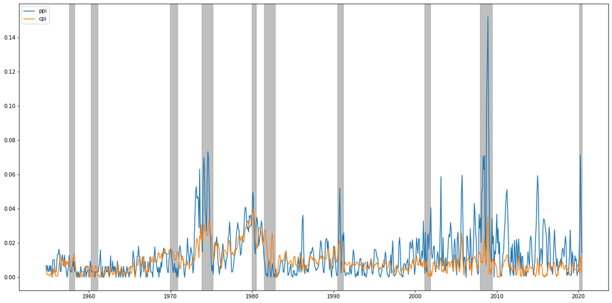

```python
ppi["PPIACO"] = abs( np.concatenate(([np.nan]*3,((ppi["PPIACO"][3:].values - ppi["PPIACO"][:-3].values)/ ppi["PPIACO"][3:].values)) ))
cpi["CPIAUCSL"] = abs( np.concatenate(([np.nan]*3,((cpi["CPIAUCSL"][3:].values - cpi["CPIAUCSL"][:-3].values)/ cpi["CPIAUCSL"][3:].values)) ))

fig = plt.figure(figsize=(20,10))
plt.plot(ppi['DATE'],ppi["PPIACO"],label='ppi')
plt.plot(cpi['DATE'],cpi["CPIAUCSL"],label='cpi')
for _, row in recess.iterrows() :
     fig.axes[0].axvspan(row["Peak month"],row["Trough month"],color='grey',alpha=0.5)
plt.legend()
```

To some degree, there seems to have a relationship but it's still unclear.  
We need data that is more smooth. To obtain such data, we need to consider the change within a longer term. So we will next try to calculate the change relative to the 28 monthes average.

[output not shown]

817 rows × 2 columns

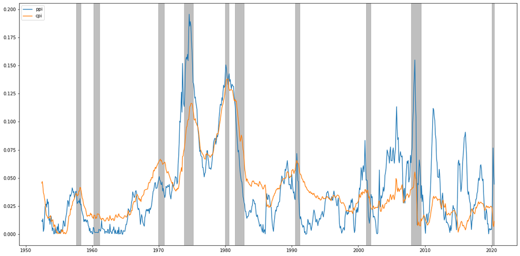

```python
#reset ppi
ppi = ppi_full[65:].copy()
cpi = cpi_full[65:].copy()
#calculate ppiavg
ppi['28avg'] = ppi['DATE'].apply(lambda r: np.average( ppi_full[(ppi_full["DATE"] >= r - pd.DateOffset(months=28)) & (ppi_full["DATE"] < r) ]["PPIACO"] ))
ppi["PPIACO"] = abs(ppi["PPIACO"] - ppi['28avg'])/ppi["PPIACO"]

#calculate cpiavg
cpi['28avg'] = cpi['DATE'].apply(lambda r: np.average( cpi_full[(cpi_full["DATE"] >= r - pd.DateOffset(months=28)) & (cpi_full["DATE"] < r) ]["CPIAUCSL"] ))
cpi["CPIAUCSL"] = abs(cpi["CPIAUCSL"] - cpi['28avg'])/cpi["CPIAUCSL"]

#draw linear graph
fig = plt.figure(figsize=(20,10))
plt.plot(ppi['DATE'],ppi["PPIACO"],label='ppi')
plt.plot(cpi['DATE'],cpi["CPIAUCSL"],label='cpi')
for _, row in recess.iterrows() :
     fig.axes[0].axvspan(row["Peak month"],row["Trough month"],color='grey',alpha=0.5)
plt.legend()
```

The grpha looks much better now!  
Genereally ppi is much more senesitive than cpi. And we should notice that while the linear relationship apears to be significant in some periods, we can hardly see a relationship from 2010-2020 and -1960. Treasury thread yiled is much more consistent overtime.

### Shiller PE S&P 500

Finally, we will take a look at the stock market. Clearly, in order to get linear relationship we can not use the price data directly. A good indicator in the stock market is the Price earning Ratio(PE)

The price-earnings ratio (P/E ratio) is ratio between a company's current share price to its earnings per share.It's a classical tool to determine if the company's undervalued or overvalued by the stock markert. You can learn more about PE from this website https://www.investopedia.com/terms/p/price-earningsratio.asp.

And what we are going to use is the P/E of the S&P500,which is a collections of majority stocks in the market. It coulde serve as a indicater to tell us if the whole market is overvalued/undervalued

We can get the pe data from https://www.quandl.com

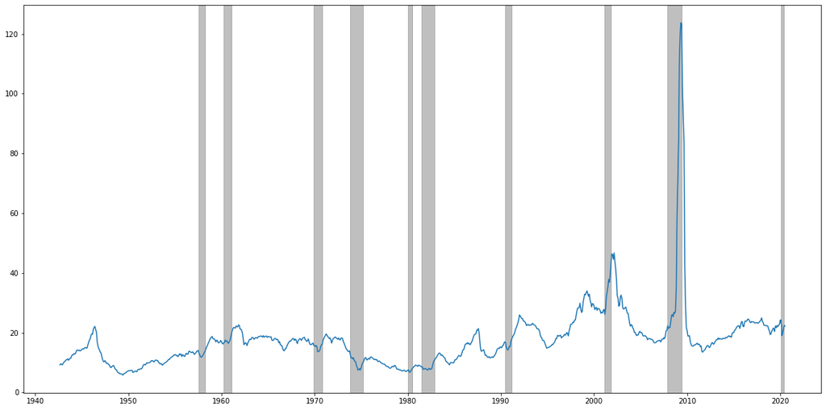

```python
#get sp p/e data
sppe = pd.read_csv("https://www.quandl.com/api/v3/datasets/MULTPL/SP500_PE_RATIO_MONTH.csv?api_key=TvLsY3Psu3xwtWufwYnG")[:-860]
# reverse the dataframe
sppe = sppe[::-1].reset_index(drop=True)
sppe['Date'] = pd.to_datetime(sppe['Date'] )

#visualization
fig = plt.figure(figsize=(20,10))
plt.plot(sppe["Date"] ,sppe["Value"])
#mark recession
for _, row in recess.iterrows() :
     fig.axes[0].axvspan(row["Peak month"],row["Trough month"],color='grey',alpha=0.5)
```

As you can see there are certain drawbacks in the way we calculate the raw PE ratio which make the data is not smooth enough (eg. aroud 2008). It's because that the earning become very unstable in the time of recession. Like ppi&cpi, We need some long term insights about the comapnies's earning ability.

Dr.shiller delveloped a new way to calculate P/E adding cyclelly adjustion to the original one. You can learn more about the new way of calculation from this: https://en.wikipedia.org/wiki/Cyclically_adjusted_price-to-earnings_ratio

We will use the data from Dr.shiller's website : http://www.econ.yale.edu/~shiller/data.htm

Since both undervalued and overvalued market could lead to recession, we will use the absolute value of the difference between current pe and a normal 25PE.

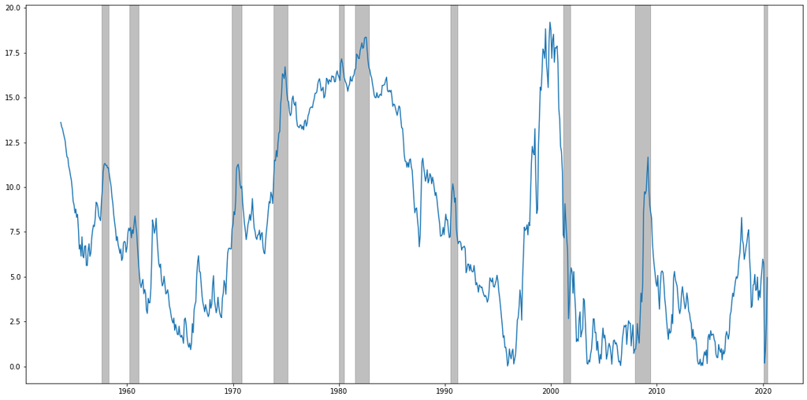

```python
#get shiller sp500 pe
sppe = pd.read_excel("http://www.econ.yale.edu/~shiller/data/ie_data.xls",1)

#clean up
sppe = sppe[["Unnamed: 0","Unnamed: 12"]][1000:-1]
sppe.columns = ["date","cape"]
sppe["date"] =pd.to_datetime(sppe["date"].apply(str).replace(r"\.1$",".10",regex=True))

#25 pe as a standard
sppe["cape"] = abs(sppe["cape"].apply(pd.to_numeric) -25)

#visualization
fig = plt.figure(figsize=(20,10))
plt.plot(sppe["date"] ,sppe["cape"])
for _, row in recess.iterrows() :
     fig.axes[0].axvspan(row["Peak month"],row["Trough month"],color='grey',alpha=0.5)
```

The grpha looks good. But again treasury yield spread shows a much more consistent relationship with recession.

## Building Model

### Logistic Regression With Treasury Yiled Spread

Since the Treasury Yiled Spread shows much more consistent relationship than others, first we will use it alone to build the regression model.

We will use sklearn's logistic Regression model. If you want to know howlogistic regression works you cna read this tutorial : https://machinelearningmastery.com/logistic-regression-for-machine-learning/

As what said previously, we will use the spread between 3month tresury and 10year treasury as samples.

For labels, we wll use the the value of this question : if there is a regression in the next n monthes? True will mark with 1 false will mark with 0

We will expore the accuracy with different n We won't use 2020 recession to train the model as it's still going on , but will use it in testing

We will use 3-fold cross validation to calculate score which means we will seperate the data into three different sets of train and test data. You can learn more about crossvalidation in https://machinelearningmastery.com/k-fold-cross-validation/

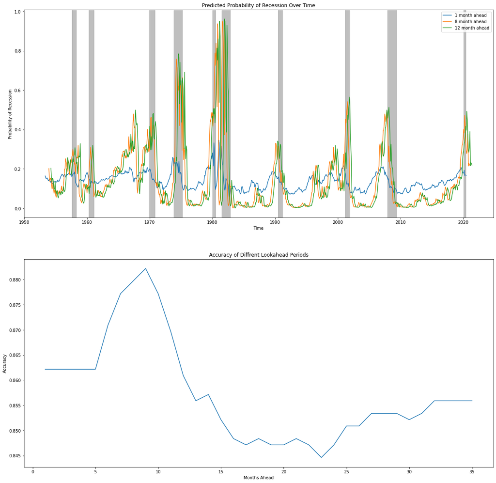

```python
#choess 3m_10y_spread to predict recession
spread = "3m_10y_spread"
treasury_rate_x = treasury_rate[["date",spread]].dropna().reset_index()


# build recess labels

#return 1 if delta monthes after dat is in arecession
def in_recess(dat,delta):
    before = (recess["Peak month"]- pd.DateOffset(months=delta)<= dat)
    after = (dat<=recess["Trough month"]-  pd.DateOffset(months=delta))
    return int((before & after).any())

recess_y = pd.DataFrame()
for i in range(36)[1:]:
    recess_y[f"{i}m_rec"] = treasury_rate_x["date"].apply(in_recess,delta=i)

#cut 2020 recession
treasury_rate_x_e = treasury_rate_x[:798].copy()
recess_y_e=recess_y[:798].copy()


#accruacy with different monthes ahead
models =[]
scores =[]
for i in range(36)[1:]:
    reg_log = linear_model.LogisticRegression()
    reg_log.fit(treasury_rate_x_e[spread].values.reshape(-1,1),recess_y_e[f"{i}m_rec"])
    models.append(reg_log)
    #cross validation
    scores.append( np.mean(cross_val_score(linear_model.LogisticRegression(),treasury_rate_x_e[spread].values.reshape(-1,1),recess_y_e[f"{i}m_rec"],cv=3)))

#visualization
fig = plt.figure(figsize=(20,20))
# draw a selected predicted probability overtime
plt.subplot(2,1,1)
plt.title("Predicted Probability of Recession Over Time")
for i in [1,8,12]:

    reg_log = models[i-1]
    pb = reg_log.predict_proba(treasury_rate_x[spread].values.reshape(-1,1))
    #date is adjusted, so that the line value directly reprecent the probility of recession in current month
    plt.plot(treasury_rate_x["date"]+pd.DateOffset(months=i),pd.DataFrame(pb)[1],label=f"{i} month ahead")

#mark recession
for _, row in recess.iterrows() :
    fig.axes[0].axvspan(row["Peak month"],row["Trough month"],color='grey',alpha=0.5)
plt.legend()
plt.ylabel("Probability of Recession")
plt.xlabel("Time")

plt.subplot(2,1,2)
plt.title("Accuracy of Diffrent Lookahead Periods")
plt.plot(range(36)[1:],scores)
plt.ylabel("Mean Accuracy in Cross Validation")
plt.xlabel("Months Ahead")
```

The first graph is 1,8,12 months ahead prediction. (Be awared that the line is moved by respective time period, so value at a month directly reprecent the model's prediction on that month despite the data we used to predict is x months ago) The second graph illustate different accurcy over different time period we choose.

From the above two graphs, one can see that the model woks great and predicts the 8-9 months ahead with best accuracy.

Then we can take a close look at the model's prediction on the recent 4 years, based on the data 8 months ago(before co the model expect there is ~50% probability of recession around feb 2020. Despite it's not over 50%, the number is high. This means Covid-19 may play a rule in the receesion 2020 but there may be some other fundemental reasons behind it.

And we can see the chance of existing recession in the end of the year is about 75% percent. But be aware that the model have no idea if the previous month is a recession, one may expect the probability of recession in the next month is higher if previous month is in a recession. It also has no idea about the situation of covid-19, in reality the progress of convid-19 will has huge imapct on the economy.

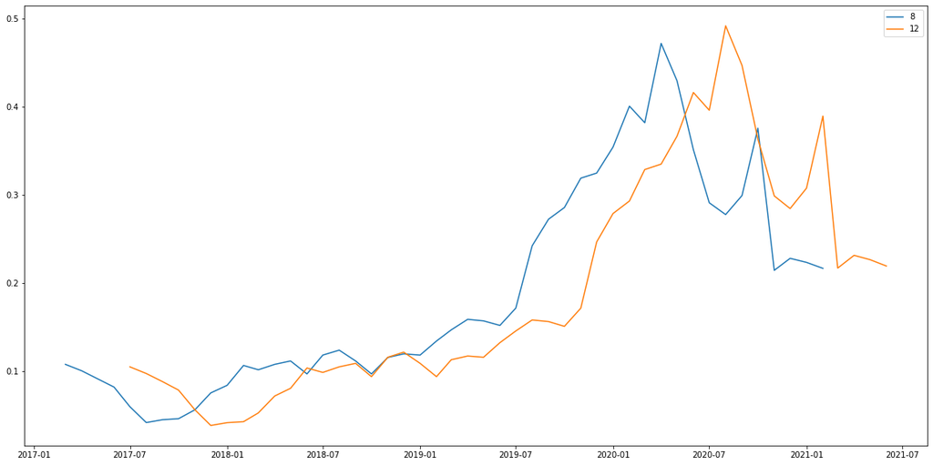

```python
fig = plt.figure(figsize=(20,10))

for i in [8,12]:

    reg_log = models[i-1]
    pb = reg_log.predict_proba(treasury_rate_x["3m_10y_spread"].values.reshape(-1,1))
    #date is adjusted, so that the line value directly reprecent the probility of recession in current month
    plt.plot((treasury_rate_x["date"]+pd.DateOffset(months=i))[-48:],pd.DataFrame(pb)[1][-48:],label=i)
plt.legend()
```

### Logistic Regression With Multivariable

Use the same setting as previous model but now we will have multiple features  
We will compare the accuracy we get from this model to the previous model.

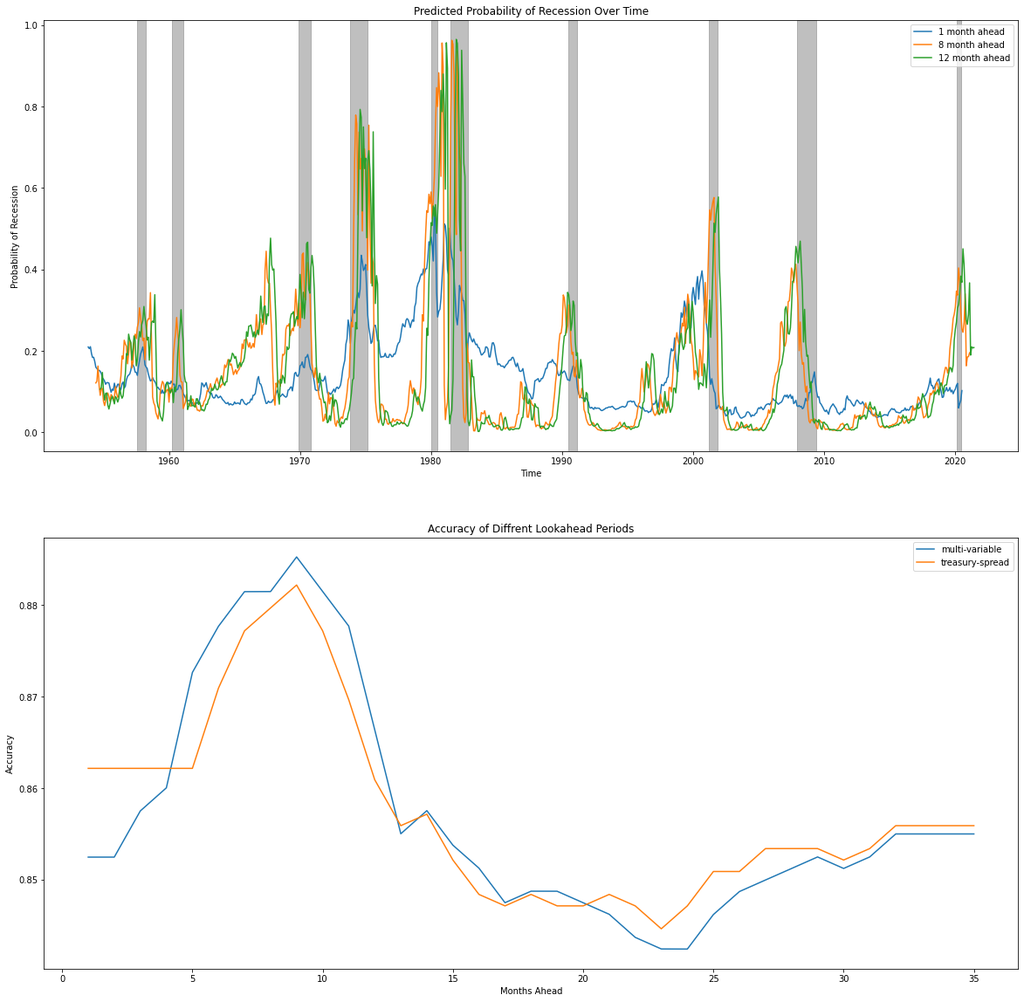

```python
#cut 2020 recession
indicators_x = treasury_rate_x[6:807].copy()
recess_y =recess_y[6:807].copy()
indicators_x['cpi'] = cpi.loc[81:881]['CPIAUCSL'].values
indicators_x['ppi'] = ppi.loc[81:881]['PPIACO'].values
indicators_x['sppe'] = sppe['cape'].values

recess_y_e = recess_y[:-8].copy()
indicators_x_e = indicators_x[:-8].copy()


#accruacy with different monthes ahead
models_multi =[]
scores_multi =[]
for i in range(36)[1:]:
    reg_log = linear_model.LogisticRegression()
    reg_log.fit(indicators_x_e[[spread,'cpi','ppi','sppe']].values,recess_y_e[f"{i}m_rec"])
    models_multi.append(reg_log)
    scores_multi.append(np.mean(cross_val_score(linear_model.LogisticRegression(),indicators_x_e[[spread,'cpi','ppi','sppe']].values,recess_y_e[f"{i}m_rec"],cv=3)))

#visualization
fig = plt.figure(figsize=(20,20))
# draw a selected predicted probability overtime
plt.subplot(2,1,1)
plt.title("Predicted Probability of Recession Over Time")
for i in [1,8,12]:

    reg_log = models_multi[i-1]
    pb = reg_log.predict_proba(indicators_x[[spread,'cpi','ppi','sppe']].values)
    #date is adjusted, so that the line value directly reprecent the probility of recession in current month
    plt.plot(indicators_x["date"]+pd.DateOffset(months=i),pd.DataFrame(pb)[1],label=f"{i} month ahead")

#mark recession
for _, row in recess.iterrows() :
    fig.axes[0].axvspan(row["Peak month"],row["Trough month"],color='grey',alpha=0.5)
plt.legend()
plt.ylabel("Probability of Recession")
plt.xlabel("Time")

plt.subplot(2,1,2)
plt.title("Accuracy of Diffrent Lookahead Periods")
plt.plot(range(36)[1:],scores_multi,label="multi-variable")
plt.plot(range(36)[1:],scores,label="treasury-spread")

plt.ylabel("Mean Accuracy in  Cross Validation ")
plt.xlabel("Months Ahead")
plt.legend()
```

We will also try to train a non-linear model

### Decision Tree

If you don't know what a decsion tree, you can read this introduction: https://www.geeksforgeeks.org/decision-tree/

Generally，decison Tree is closer to the way we make decision which means it could be more easy to understand when the depth is low.

[figure not shown]

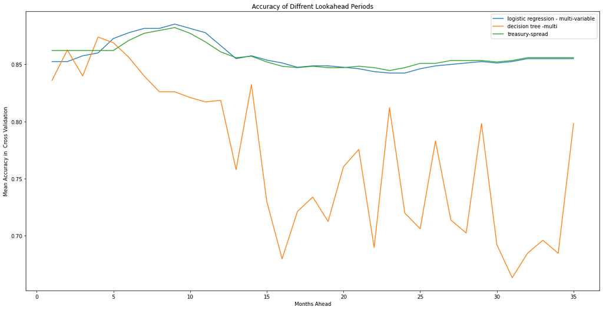

```python
models_multi_dec =[]
scores_multi_dec =[]
for i in range(36)[1:]:
    decision_tree = DecisionTreeClassifier(max_depth=1)
    decision_tree.fit(indicators_x_e[[spread,'cpi','ppi','sppe']].values,recess_y_e[f"{i}m_rec"])
    models_multi_dec.append(decision_tree)
    #cross validation
    scores_multi_dec.append(np.mean(cross_val_score(DecisionTreeClassifier(max_depth=4),indicators_x_e[[spread,'cpi','ppi','sppe']].values,recess_y_e[f"{i}m_rec"],cv=3)))

#visualization
fig = plt.figure(figsize=(20,10))

plt.title("Accuracy of Diffrent Lookahead Periods")
plt.plot(range(36)[1:],scores_multi,label="logistic regression - multi-variable")
plt.plot(range(36)[1:],scores_multi_dec,label="decision tree -multi")
plt.plot(range(36)[1:],scores,label="treasury-spread")

plt.ylabel("Mean Accuracy in  Cross Validation")
plt.xlabel("Months Ahead")
plt.legend()

# Create DOT data
dot_data = tree.export_graphviz(models_multi_dec[4-1], out_file=None,feature_names=[spread,"cpi","ppi","sppe"],
                                class_names=["recission","not recession"])

# Draw graph
graph = pydotplus.graph_from_dot_data(dot_data)

# Show graph
Image(graph.create_png())
```

## Conclusion

After explore different model to predict recessions, you should notice that it's not always the case that more features lead to better model. Simple feature and simple decision could lead to decent result. Since the best accuracys of these models are similar, we can just use the first model to answer the questions proposed at the very start.

- Treasury Yield Spread regression model expect a high risk ~50% 8-12 months before Feb 2020
- Perhaps COVID-19 may not be the pure reason for this recession
- We have 75+% probability to get out of recession at the end of the year, but in reality this shoul be lower and it really depends on COVID-19